# Public Mutation Database and Ovarian Cancer Survival Analysis

## Correlation study

### Use `apply` to see correlation between methylation and expression level

```r
apply(met[,-1], 1, function(x) cor(x, brca1.exp))
```

```
## [1]         NA         NA         NA -0.4851047         NA -0.4926496 -0.3203310
## [8] -0.4598128 -0.0175344
```

### Use for loop to do the same thing

```r
cor.result <- list()
for (i in c(1:9))
  cor.result[i] <- cor(as.numeric(met[i, -1]), brca1.exp)
cor.result
```

```
## [[1]]
## [1] NA
##
## [[2]]
## [1] NA
##
## [[3]]
## [1] NA
##
## [[4]]
## [1] -0.4851047
##
## [[5]]
## [1] NA
##
## [[6]]
## [1] -0.4926496
##
## [[7]]
## [1] -0.320331
##
## [[8]]
## [1] -0.4598128
##
## [[9]]
## [1] -0.0175344
```

Draw a heatmap that has high correlation with BRCA1 expression level. If the methylation probe has particularly high correlation (0.3<) with BRCA1 expression level or particularly low correlation w/ BRCA1 expression level (-0.3>), print it out in a heatmap. As we’ve seen from above, use the `apply` function to find the pearson correlation coefficient between BRCA1 expression level and each methylation probe’s beta value.

```r
exp.cor <- apply(met[,-1], 1, function(x) cor(x, brca1.exp))
```

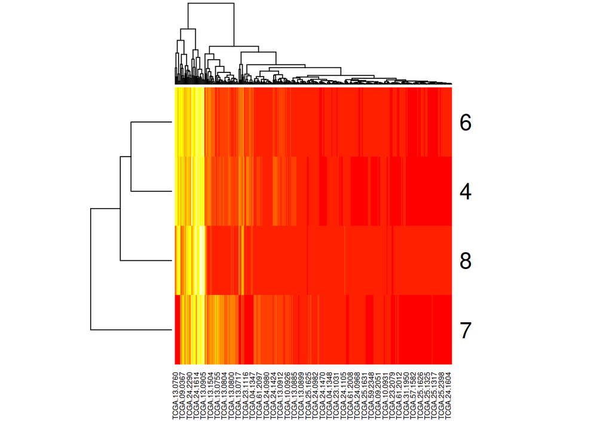

```r
# row-wise, bring
TestMatrix <- met[which(abs(exp.cor)>0.3), -1]
# Next, find the samples where BRCA1 methylation patterns are different. (because we took abs of exp.cor)
heatmap(as.matrix(TestMatrix), scale="row", col=heat.colors(12)) # Draw heatmap
```

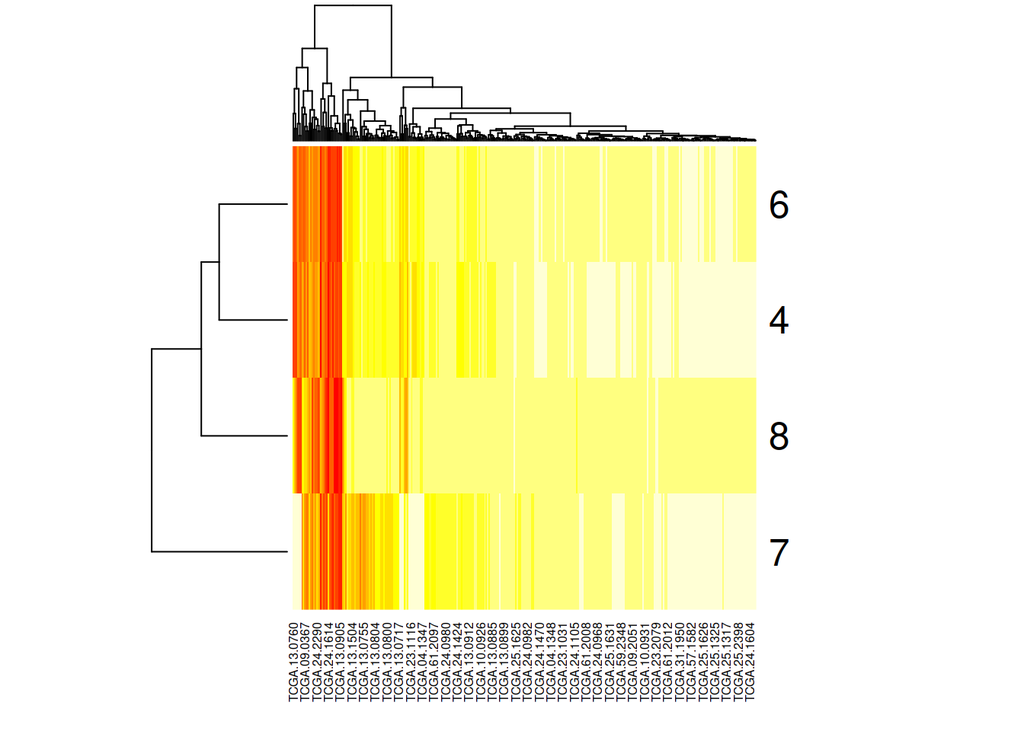

```r
# If you want to reverse it, you can use rev
heatmap(as.matrix(TestMatrix), scale="row", col=rev(heat.colors(12)))
```

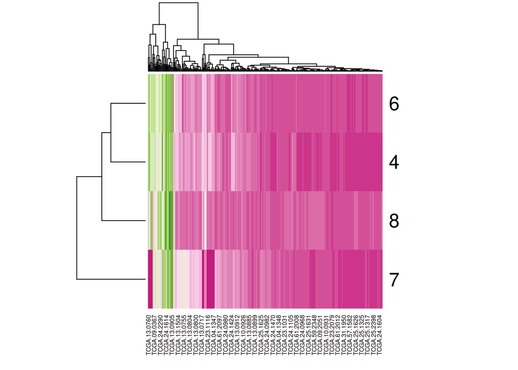

```r
# Curiously enough, the default is set at reverse of heat.colors(12)

# or you can also use RColorBrewer

library(RColorBrewer)
coul <- colorRampPalette(brewer.pal(8, "PiYG"))(25)
heatmap(as.matrix(TestMatrix), scale="row", col = coul)
```

`heat.colors()` function takes number of heat gradients as the argument.

Refer to R Graph Gallery for more info about heatmap function and color palette: [r-graph-gallery](https://www.r-graph-gallery.com/215-the-heatmap-function.html)

Why is the heat color reversed? Completely perplexed…

```r
exp.cor
```

```
## [1]         NA         NA         NA -0.4851047         NA -0.4926496 -0.3203310
## [8] -0.4598128 -0.0175344
```

Now, `hclust` performs what is called the hierarchical clustering. (Refer to https://bioinformaticsandme.tistory.com/145, https://www.displayr.com/what-is-hierarchical-clustering/, https://ratsgo.github.io/machine%20learning/2017/04/18/HC/) The endpoint of hierarchical clustering is a set of clusters where each cluster is distinct from each other cluster, and the objects within each cluster are broadly similar to each other.

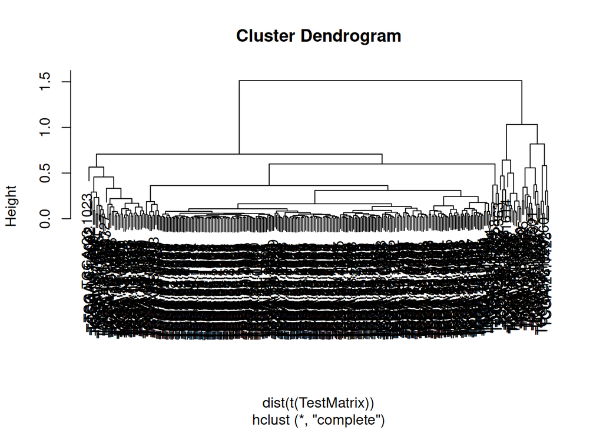

```r
AA <- hclust(dist(t(TestMatrix)))
plot(AA)
```

```r
M <- identify(AA)
```

`identify(AA)` is the function where you select the cluster and take the sample names of that group from dendrogram graphic viewer to a list, by clicking the cluster on the right. So you gotta execute it in the console to proceed to the next. Then you gotta press ESC to stop selecting and assign the obtained list to **M**.

You can also use `hclust` to divide the clusters into certain groups and choose among them with an index.

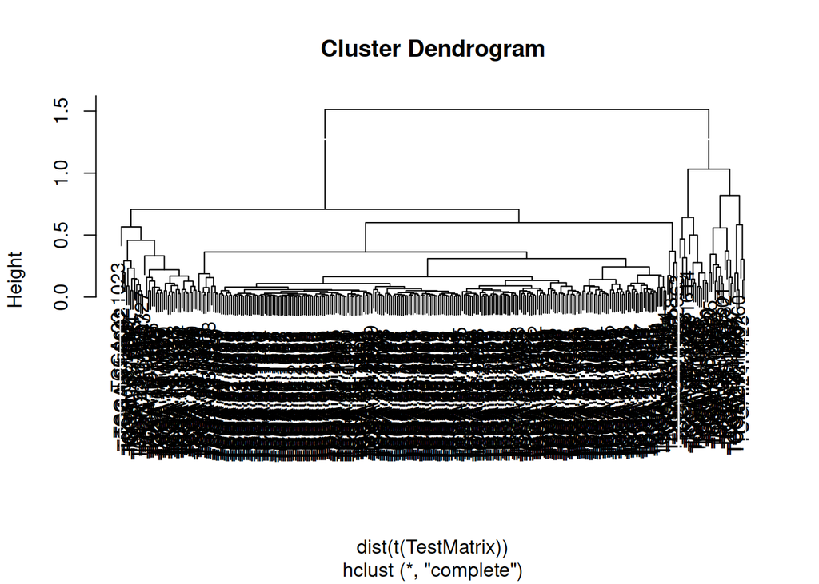

```r
plot(AA)
M <- rect.hclust(AA, h=1.3, border=0)[2]
```

```r
M
```

```
## [[1]]
## TCGA.04.1361 TCGA.04.1362 TCGA.09.0367 TCGA.09.1665 TCGA.09.2044 TCGA.10.0928
##           16           17           29           34           37           46
## TCGA.10.0937 TCGA.13.0725 TCGA.13.0760 TCGA.13.0792 TCGA.13.0897 TCGA.13.0905
##           52           59           64           71           88           94
## TCGA.13.0916 TCGA.13.0920 TCGA.13.1482 TCGA.13.1483 TCGA.13.1497 TCGA.13.1501
##          100          102          115          116          125          128
## TCGA.13.1510 TCGA.23.1022 TCGA.23.1117 TCGA.24.1423 TCGA.24.1425 TCGA.24.1428
##          134          141          154          181          183          186
## TCGA.24.1435 TCGA.24.1557 TCGA.24.1567 TCGA.24.1614 TCGA.24.2289 TCGA.24.2290
##          189          208          215          218          232          233
## TCGA.25.1313 TCGA.25.1326 TCGA.36.1568 TCGA.59.2363
##          236          247          276          296
```

Assign the samples that have differential methylation pattern to a variable.

```r
brca1.met <- names(met[, as.numeric(M[[1]])])
brca1.met
```

```
##  [1] "TCGA.04.1357" "TCGA.04.1361" "TCGA.09.0366" "TCGA.09.1662" "TCGA.09.1669"
##  [6] "TCGA.10.0927" "TCGA.10.0935" "TCGA.13.0724" "TCGA.13.0758" "TCGA.13.0791"
## [11] "TCGA.13.0894" "TCGA.13.0904" "TCGA.13.0913" "TCGA.13.0919" "TCGA.13.1481"
## [16] "TCGA.13.1482" "TCGA.13.1496" "TCGA.13.1499" "TCGA.13.1509" "TCGA.23.1021"
## [21] "TCGA.23.1116" "TCGA.24.1422" "TCGA.24.1424" "TCGA.24.1427" "TCGA.24.1434"
## [26] "TCGA.24.1556" "TCGA.24.1565" "TCGA.24.1604" "TCGA.24.2288" "TCGA.24.2289"
## [31] "TCGA.24.2298" "TCGA.25.1325" "TCGA.31.1950" "TCGA.59.2355"
```

# VI. Survival Analysis

Lastly, we do survival analysis using clinical data.

## Set types of samples (brca1.met, brca1.mut, brca2.mut) and `gsub` to unify format

```r
dim(cli)
```

```
## [1] 317  44
```

```r
type <- c(rep('wild', 317)) # Repeat 317 times of wild and make it into a vector
```

Assign patient barcode to names.

```r
names(type) <- cli[, 1] # The first column is patient barcode.
```

Change the format because they’re different. brca1.met has dot (“.”) and brca1.mut has dash (“-”).

```r
brca1.met <- gsub(".", "-", brca1.met, fixed=T)
#fixed = TRUE argument means the pattern is a string to be matched as is, not as a regular expression.
```

```r
brca1.mut
```

```
## [1] "TCGA-13-0730" "TCGA-13-0761" "TCGA-25-1625" "TCGA-24-2035" "TCGA-04-1357"
## [6] "TCGA-29-2427" "TCGA-13-1489" "TCGA-13-0804"
```

```r
brca2.mut
```

```
##  [1] "TCGA-13-0792" "TCGA-24-1555" "TCGA-23-1120" "TCGA-04-1331" "TCGA-23-1030"
##  [6] "TCGA-09-2050" "TCGA-13-0890" "TCGA-13-0885" "TCGA-24-1103" "TCGA-13-1481"
```

```r
brca1.met
```

```
##  [1] "TCGA-04-1357" "TCGA-04-1361" "TCGA-09-0366" "TCGA-09-1662" "TCGA-09-1669"
##  [6] "TCGA-10-0927" "TCGA-10-0935" "TCGA-13-0724" "TCGA-13-0758" "TCGA-13-0791"
## [11] "TCGA-13-0894" "TCGA-13-0904" "TCGA-13-0913" "TCGA-13-0919" "TCGA-13-1481"
## [16] "TCGA-13-1482" "TCGA-13-1496" "TCGA-13-1499" "TCGA-13-1509" "TCGA-23-1021"
## [21] "TCGA-23-1116" "TCGA-24-1422" "TCGA-24-1424" "TCGA-24-1427" "TCGA-24-1434"
## [26] "TCGA-24-1556" "TCGA-24-1565" "TCGA-24-1604" "TCGA-24-2288" "TCGA-24-2289"
## [31] "TCGA-24-2298" "TCGA-25-1325" "TCGA-31-1950" "TCGA-59-2355"
```

```r
type[brca1.mut]
```

```
## TCGA-13-0730 TCGA-13-0761 TCGA-25-1625 TCGA-24-2035 TCGA-04-1357 TCGA-29-2427
##       "wild"       "wild"       "wild"       "wild"       "wild"       "wild"
## TCGA-13-1489 TCGA-13-0804
##       "wild"       "wild"
```

```r
type[brca1.met] = 'brca1.met'
type[brca1.mut] = 'brca1.mut'
type[brca2.mut] = 'brca2.mut'
```

```r
type
```

```
## TCGA-04-1331 TCGA-04-1332 TCGA-04-1336 TCGA-04-1337 TCGA-04-1338 TCGA-04-1342
##  "brca2.mut"       "wild"       "wild"       "wild"       "wild"       "wild"
## TCGA-04-1343 TCGA-04-1346 TCGA-04-1347 TCGA-04-1348 TCGA-04-1349 TCGA-04-1350
##       "wild"       "wild"       "wild"       "wild"       "wild"       "wild"
## TCGA-04-1351 TCGA-04-1356 TCGA-04-1357 TCGA-04-1361 TCGA-04-1362 TCGA-04-1364
##       "wild"       "wild"  "brca1.mut"  "brca1.met"       "wild"       "wild"
## TCGA-04-1365 TCGA-04-1367 TCGA-04-1514 TCGA-04-1517 TCGA-04-1519 TCGA-04-1525
##       "wild"       "wild"       "wild"       "wild"       "wild"       "wild"
## TCGA-04-1530 TCGA-04-1542 TCGA-09-0364 TCGA-09-0366 TCGA-09-0367 TCGA-09-0369
##       "wild"       "wild"       "wild"  "brca1.met"       "wild"       "wild"
## TCGA-09-1659 TCGA-09-1661 TCGA-09-1662 TCGA-09-1665 TCGA-09-1666 TCGA-09-1669
##       "wild"       "wild"  "brca1.met"       "wild"       "wild"  "brca1.met"
## TCGA-09-2044 TCGA-09-2045 TCGA-09-2049 TCGA-09-2050 TCGA-09-2051 TCGA-09-2053
##       "wild"       "wild"       "wild"  "brca2.mut"       "wild"       "wild"
## TCGA-09-2056 TCGA-10-0926 TCGA-10-0927 TCGA-10-0928 TCGA-10-0930 TCGA-10-0931
##       "wild"       "wild"  "brca1.met"       "wild"       "wild"       "wild"
## TCGA-10-0933 TCGA-10-0934 TCGA-10-0935 TCGA-10-0937 TCGA-10-0938 TCGA-13-0714
##       "wild"       "wild"  "brca1.met"       "wild"       "wild"       "wild"
## TCGA-13-0717 TCGA-13-0720 TCGA-13-0723 TCGA-13-0724 TCGA-13-0725 TCGA-13-0727
##       "wild"       "wild"       "wild"  "brca1.met"       "wild"       "wild"
## TCGA-13-0730 TCGA-13-0755 TCGA-13-0758 TCGA-13-0760 TCGA-13-0761 TCGA-13-0762
##  "brca1.mut"       "wild"  "brca1.met"       "wild"  "brca1.mut"       "wild"
## TCGA-13-0764 TCGA-13-0765 TCGA-13-0766 TCGA-13-0791 TCGA-13-0792 TCGA-13-0793
##       "wild"       "wild"       "wild"  "brca1.met"  "brca2.mut"       "wild"
## TCGA-13-0795 TCGA-13-0800 TCGA-13-0801 TCGA-13-0802 TCGA-13-0804 TCGA-13-0807
##       "wild"       "wild"       "wild"       "wild"  "brca1.mut"       "wild"
## TCGA-13-0883 TCGA-13-0884 TCGA-13-0885 TCGA-13-0886 TCGA-13-0887 TCGA-13-0890
##       "wild"       "wild"  "brca2.mut"       "wild"       "wild"  "brca2.mut"
## TCGA-13-0891 TCGA-13-0893 TCGA-13-0894 TCGA-13-0897 TCGA-13-0899 TCGA-13-0900
##       "wild"       "wild"  "brca1.met"       "wild"       "wild"       "wild"
## TCGA-13-0901 TCGA-13-0903 TCGA-13-0904 TCGA-13-0905 TCGA-13-0906 TCGA-13-0910
##       "wild"       "wild"  "brca1.met"       "wild"       "wild"       "wild"
## TCGA-13-0911 TCGA-13-0912 TCGA-13-0913 TCGA-13-0916 TCGA-13-0919 TCGA-13-0920
##       "wild"       "wild"  "brca1.met"       "wild"  "brca1.met"       "wild"
## TCGA-13-0923 TCGA-13-0924 TCGA-13-1403 TCGA-13-1404 TCGA-13-1405 TCGA-13-1407
##       "wild"       "wild"       "wild"       "wild"       "wild"       "wild"
## TCGA-13-1408 TCGA-13-1409 TCGA-13-1411 TCGA-13-1412 TCGA-13-1477 TCGA-13-1481
##       "wild"       "wild"       "wild"       "wild"       "wild"  "brca2.mut"
## TCGA-13-1482 TCGA-13-1483 TCGA-13-1484 TCGA-13-1488 TCGA-13-1489 TCGA-13-1491
##  "brca1.met"       "wild"       "wild"       "wild"  "brca1.mut"       "wild"
```

[output cut: 51 more lines]

```
##       "wild"       "wild"  "brca1.mut"       "wild"  "brca1.met"       "wild"
## TCGA-36-1569 TCGA-36-1570 TCGA-36-1571 TCGA-36-1574 TCGA-36-1575 TCGA-36-1576
##       "wild"       "wild"       "wild"       "wild"       "wild"       "wild"
## TCGA-36-1577 TCGA-36-1578 TCGA-36-1580 TCGA-57-1582 TCGA-57-1583 TCGA-57-1584
##       "wild"       "wild"       "wild"       "wild"       "wild"       "wild"
## TCGA-57-1993 TCGA-59-2348 TCGA-59-2350 TCGA-59-2351 TCGA-59-2352 TCGA-59-2354
##       "wild"       "wild"       "wild"       "wild"       "wild"       "wild"
## TCGA-59-2355 TCGA-59-2363 TCGA-61-1728 TCGA-61-1736 TCGA-61-1995 TCGA-61-1998
##  "brca1.met"       "wild"       "wild"       "wild"       "wild"       "wild"
## TCGA-61-2000 TCGA-61-2002 TCGA-61-2003 TCGA-61-2008 TCGA-61-2009 TCGA-61-2012
##       "wild"       "wild"       "wild"       "wild"       "wild"       "wild"
## TCGA-61-2016 TCGA-61-2092 TCGA-61-2094 TCGA-61-2095 TCGA-61-2097 TCGA-61-2101
##       "wild"       "wild"       "wild"       "wild"       "wild"       "wild"
## TCGA-61-2102 TCGA-61-2104 TCGA-61-2109 TCGA-61-2111 TCGA-61-2113
##       "wild"       "wild"       "wild"       "wild"       "wild"
```

## Survival Analysis

```r
library(survival)
out <- survfit(Surv(cli$days_to_last_followup) ~ type)
```

This means, make survival analysis object with clinical data’s days_to_last_followup column value with `type` as the variable to analyze against. There are total of four categories for survival analysis: *wild*, *brca1.met*, *brca1.mut*, *brca2.mut*.

[figure not shown]

```r
color <- c("green", "blue", "red", "black") # make vector to designate each of the four categories
plot(out, col=color, main="Association of BRCA1/2 Mutations with Survival", xlab="Time, days", ylab="Proportion") #plot

legend(4200, 0.9, c("BRCA1 mutation", "BRCA1 methylation", "BRCA2 mutation", "wild"), col=color, lty=1, lwd=3)
```

Rest of the clusters (groups) don’t show much of difference from wildtype Kaplan-Meier survival curve.

However, BRCA2 mutation shows notable difference from wildtype in survival rate. Therefore, BRCA2 mutation shows better prognosis than wildtype and BRCA1 mutation, BRCA1 differential expression (differential methylation) group.

However, does differential methylation directly correlate with differential expression? I’m not sure.

[^1]: [Yang D, Khan S, Sun Y, et al. Association of BRCA1 and BRCA2 Mutations With Survival, Chemotherapy Sensitivity, and Gene Mutator Phenotype in Patients With Ovarian Cancer. JAMA. 2011;306(14):1557–1565. doi:10.1001/jama.2011.1456](https://jamanetwork.com/journals/jama/fullarticle/1104495)